# iDEP: Investigating Differentially Expressed Genes

## If this site has contributed to your work, please cite our article:

Ge, S.X., Son, E.W. & Yao, R. iDEP: an integrated web application for differential expression and pathway analysis of RNA-Seq data. BMC Bioinformatics 19, 534 (2018). https://doi.org/10.1186/s12859-018-2486-6

## Summary

Read Counts data were analyzed using iDEP v2.4.3. The data was first filtered to remove reads below 0.5 CPM in at least 1 sample. Then the data was transformed with EdgeR using a pseudocount of 4. Missing values were imputed using geneMedian.

After mapping, there are 42278 unique genes in 31 samples. Of the 30756 genes passed filter, 30695 were converted to Ensembl/STRING gene IDs in our database. The remaining 61 genes were kept in the data using original IDs.

Differential expression analysis was performed using DESeq2 with an FDR cutoff of 0.1 and a minimum fold-change threshold of 2. Standard Wald test was used and independent filtering was disabled.

## Selected Comparison: ANTHO_LESS_&*40_CGY-WT*&_40_CGY

Up-regulated genes: 58

Down-regulated genes: 72

## Top Up-regulated Genes

```r
if (!is.null(params$up_genes_table) && nrow(params$up_genes_table) > 0) {
  kbl(params$up_genes_table, escape = FALSE) %>%
    kable_classic(full_width = FALSE, html_font = "Cambria")
} else {
  print("No up-regulated genes found for this comparison.")
}
```

| Symbol | Ensembl ID | log2 FC | Adj. P-value | Description |
| --- | --- | --- | --- | --- |
| BRA038304 | BRA038304 | 23.754 | 6.70e-09 | AT3G31430 (E=6e-025) \| unknown protein |
| BRA002786 | BRA002786 | 5.471 | 5.51e-02 | AT5G56890 (E=0.0) \| protein kinase family protein |
| BRA040293 | BRA040293 | 4.896 | 1.16e-03 | AT3G06830 (E=3e-252) \| pectinesterase family protein |
| BRA016183 | BRA016183 | 4.766 | 5.06e-03 | AT2G07760 (E=3e-015) \| zinc knuckle (CCHC-type) family protein |
| BRA005456 | BRA005456 | 4.244 | 5.93e-02 | AT2G34060 (E=3e-123) \| peroxidase, putative |
| BRA005458 | BRA005458 | 4.244 | 5.93e-02 | AT2G34060 (E=3e-123) \| peroxidase, putative |
| BRA020310 | BRA020310 | 4.002 | 3.38e-02 | AT5G59580 (E=3e-218) UGT76E1 \| UGT76E1 (UDP-GLUCOSYL TRANSFERASE 76E1) |
| BRA025281 | BRA025281 | 3.790 | 1.84e-02 | AT4G27710 (E=2e-218) CYP709B3 \| CYP709B3 |
| BRA013390 | BRA013390 | 3.740 | 8.54e-02 | AT4G19370 (E=1e-089) \| unknown protein |
| BRA011017 | BRA011017 | 3.723 | 5.34e-03 | AT1G26210 (E=7e-023) \| unknown protein |
| BRA003792 | BRA003792 | 3.639 | 4.91e-02 |  |
| BRA025198 | BRA025198 | 3.613 | 1.66e-02 | AT3G26290 (E=2e-225) CYP71B26 \| CYP71B26 |
| BRA005423 | BRA005423 | 3.560 | 5.59e-07 | AT2G34420 (E=8e-101) LHB1B2, LHCB1.5 \| LHB1B2 |
| BRA040103 | BRA040103 | 3.447 | 8.46e-02 |  |
| BRA032425 | BRA032425 | 3.378 | 6.84e-02 |  |
| BRA032170 | BRA032170 | 3.221 | 6.00e-02 | AT2G23360 (E=1e-280) \| transport protein-related |
| BRA033627 | BRA033627 | 3.199 | 9.22e-02 | AT4G39530 (E=0.0) \| pentatricopeptide (PPR) repeat-containing protein |
| BRA029502 | BRA029502 | 3.144 | 3.95e-02 |  |
| BRA031247 | BRA031247 | 3.127 | 5.28e-02 | AT3G21055 (E=3e-019) PSBTN \| PSBTN (photosystem II subunit T) |
| BRA020022 | BRA020022 | 2.954 | 2.97e-02 | AT5G26770 (E=2e-074) \| unknown protein |
| BRA010602 | BRA010602 | 2.940 | 2.72e-02 | AT4G37580 (E=1e-215) HLS1, COP3, UNS2 \| HLS1 (HOOKLESS 1) |
| BRA029936 | BRA029936 | 2.741 | 9.06e-02 | AT3G49160 (E=7e-293) \| pyruvate kinase family protein |
| BRA025340 | BRA025340 | 2.721 | 3.26e-02 | AT3G28510 (E=6e-203) \| AAA-type ATPase family protein |
| BRA027533 | BRA027533 | 2.633 | 3.12e-02 | AT5G44170 (E=9e-108) \| FUNCTIONS IN: molecular_function unknown |
| BRA021706 | BRA021706 | 2.339 | 1.02e-02 | AT1G06200 (E=1e-009) \| serine-type peptidase |
| BRA036791 | BRA036791 | 2.333 | 5.04e-03 | AT3G51560 (E=0.0) \| ATP binding / protein binding / transmembrane receptor |
| BRA012891 | BRA012891 | 2.291 | 2.03e-03 | AT3G50750 (E=1e-111) \| brassinosteroid signalling positive regulator-related |
| LSU_rRNA_eukarya ENSRNA049460011 | ENSRNA049460011 | 2.262 | 3.83e-02 | Eukaryotic large subunit ribosomal RNA |
| BRA020161 | BRA020161 | 2.225 | 6.78e-02 | AT5G21950 (E=1e-144) \| hydrolase, alpha/beta fold family protein |
| BRA014873 | BRA014873 | 2.218 | 3.13e-02 |  |
| BRA017655 | BRA017655 | 2.177 | 6.79e-02 |  |
| BRA006303 | BRA006303 | 2.165 | 3.11e-02 | AT5G15490 (E=4e-277) \| UDP-glucose 6-dehydrogenase, putative |
| BRA014106 | BRA014106 | 2.109 | 4.46e-02 | AT2G47450 (E=7e-149) CAO, CPSRP43 \| CAO (CHAOS) |
| BRA013985 | BRA013985 | 2.077 | 8.54e-02 | AT5G17350 (E=2e-070) \| unknown protein |
| BRA033478 | BRA033478 | 1.980 | 5.93e-02 | AT1G54500 (E=3e-042) \| rubredoxin family protein |
| BRA002984 | BRA002984 | 1.967 | 3.76e-02 | AT4G27280 (E=6e-051) \| calcium-binding EF hand family protein |
| BRA041148 | BRA041148 | 1.920 | 4.90e-03 |  |
| BRA015050 | BRA015050 | 1.919 | 7.57e-04 | AT3G24520 (E=1e-113) AT-HSFC1, HSFC1 \| AT-HSFC1 |
| BRA002617 | BRA002617 | 1.864 | 9.08e-03 | AT3G47070 (E=3e-025) \| unknown protein |
| BRA010473 | BRA010473 | 1.828 | 9.06e-02 | AT4G25230 (E=2e-249) RIN2 \| RIN2 (RPM1 INTERACTING PROTEIN 2) |
| BRA038498 | BRA038498 | 1.827 | 1.35e-02 | AT4G16680 (E=0.0) \| RNA helicase, putative |
| BRA021171 | BRA021171 | 1.824 | 2.43e-02 | AT3G16240 (E=2e-100) DELTA-TIP, TIP2 |
| BRA016144 | BRA016144 | 1.751 | 6.06e-02 | AT1G71360 (E=1e-168) \| FUNCTIONS IN: molecular_function unknown |
| BRA041155 | BRA041155 | 1.649 | 3.00e-03 |  |
| BRA031945 | BRA031945 | 1.628 | 7.35e-02 | AT3G04100 (E=4e-034) AGL57 \| AGL57 |
| BRA018810 | BRA018810 | 1.625 | 6.61e-02 | AT5G43730 (E=7e-067) \| disease resistance protein (CC-NBS-LRR class), putative |
| 5_8S_rRNA ENSRNA049460362 | ENSRNA049460362 | 1.621 | 7.76e-02 | 5.8S ribosomal RNA |
| BRA002537 | BRA002537 | 1.616 | 1.00e-02 | AT5G59730 (E=2e-262) ATEXO70H7 \| ATEXO70H7 (EXOCYST SUBUNIT EXO70 FAMILY PROTEIN H7) |
| BRA016941 | BRA016941 | 1.616 | 1.75e-02 | AT2G41330 (E=6e-102) \| glutaredoxin family protein |
| BRA007055 | BRA007055 | 1.584 | 7.75e-02 | AT3G54210 (E=1e-078) \| ribosomal protein L17 family protein |

## Top Down-regulated Genes

```r
if (!is.null(params$down_genes_table) && nrow(params$down_genes_table) > 0) {
  kbl(params$down_genes_table, escape = FALSE) %>%
    kable_classic(full_width = FALSE, html_font = "Cambria")
} else {
  print("No down-regulated genes found for this comparison.")
}
```

| Symbol | Ensembl ID | log2 FC | Adj. P-value | Description |
| --- | --- | --- | --- | --- |
| BRA012114 | BRA012114 | -5.412 | 8.73e-02 | AT5G66900 (E=3e-217) \| disease resistance protein (CC-NBS-LRR class), putative |
| BRA018419 | BRA018419 | -4.878 | 5.59e-02 | AT1G10880 (E=1e-186) \| unknown protein |
| BRA023863 | BRA023863 | -4.501 | 2.67e-02 | AT3G21760 (E=1e-197) \| UDP-glucoronosyl/UDP-glucosyl transferase family protein |
| BRA028219 | BRA028219 | -4.212 | 5.06e-03 | AT5G39000 (E=0.0) \| protein kinase family protein |
| BRA037456 | BRA037456 | -4.151 | 4.45e-02 | AT5G48850 (E=8e-156) ATSDI1 \| ATSDI1 (SULPHUR DEFICIENCY-INDUCED 1) |
| BRA033775 | BRA033775 | -4.147 | 5.93e-02 | AT3G48090 (E=3e-194) EDS1 \| EDS1 (enhanced disease susceptibility 1) |
| BRA008847 | BRA008847 | -4.124 | 8.29e-02 | AT5G13210 (E=3e-275) \| CONTAINS InterPro DOMAIN/s: Uncharacterized conserved protein UCP015417, vWA (InterPro:IPR011205), von Willebrand factor, type A (InterPro:IPR002035) |
| BRA000034 | BRA000034 | -3.981 | 5.06e-03 | AT2G37990 (E=4e-118) \| ribosome biogenesis regulatory protein (RRS1) family protein |
| BRA001474 | BRA001474 | -3.868 | 9.75e-03 | AT3G12860 (E=1e-235) \| nucleolar protein Nop56, putative |
| BRA015346 | BRA015346 | -3.810 | 1.09e-02 | AT1G04770 (E=5e-150) \| male sterility MS5 family protein |
| BRA012767 | BRA012767 | -3.802 | 1.35e-02 | AT4G15760 (E=2e-190) MO1 \| MO1 (MONOOXYGENASE 1) |
| BRA036936 | BRA036936 | -3.710 | 4.92e-02 | AT1G43910 (E=2e-221) \| AAA-type ATPase family protein |
| BRA037463 | BRA037463 | -3.647 | 5.93e-02 | AT5G48740 (E=0.0) \| leucine-rich repeat family protein / protein kinase family protein |
| BRA017888 | BRA017888 | -3.524 | 3.12e-02 | AT1G60140 (E=0.0) ATTPS10, TPS10 \| ATTPS10 (trehalose phosphate synthase) |
| BRA031351 | BRA031351 | -3.460 | 9.06e-02 | AT3G22370 (E=2e-166) AOX1A, ATAOX1A \| AOX1A (ALTERNATIVE OXIDASE 1A) |
| BRA029775 | BRA029775 | -3.360 | 9.06e-02 | AT3G09570 (E=2e-205) \| FUNCTIONS IN: molecular_function unknown |
| BRA014494 | BRA014494 | -3.358 | 3.10e-02 | AT3G60360 (E=8e-099) EDA14, UTP11 \| EDA14 (EMBRYO SAC DEVELOPMENT ARREST 14) |
| BRA038962 | BRA038962 | -3.251 | 6.13e-02 | AT4G14020 (E=3e-027) \| rapid alkalinization factor (RALF) family protein |
| BRA027673 | BRA027673 | -3.155 | 2.32e-02 | AT1G63980 (E=1e-148) \| D111/G-patch domain-containing protein |
| BRA004512 | BRA004512 | -3.138 | 3.00e-03 | AT2G46740 (E=2e-304) \| FAD-binding domain-containing protein |
| BRA017004 | BRA017004 | -3.106 | 3.51e-02 | AT2G40430 (E=3e-069) \| FUNCTIONS IN: molecular_function unknown |
| BRA000159 | BRA000159 | -3.090 | 4.57e-02 | AT2G40010 (E=8e-149) \| 60S acidic ribosomal protein P0 (RPP0A) |
| BRA013887 | BRA013887 | -3.085 | 5.76e-03 | AT4G25340 (E=3e-136) \| immunophilin-related / FKBP-type peptidyl-prolyl cis-trans isomerase-related |
| BRA030202 | BRA030202 | -3.077 | 2.97e-02 | AT2G22795 (E=1e-027) \| unknown protein |
| BRA020209 | BRA020209 | -3.063 | 4.90e-03 | AT5G22650 (E=7e-029) HD2B, HDT02, HDT2, ATHD2B, HDA4, HD2 \| HD2B (HISTONE DEACETYLASE 2B) |
| BRA000317 | BRA000317 | -2.752 | 3.10e-02 | AT2G43650 (E=5e-192) EMB2777 \| EMB2777 (EMBRYO DEFECTIVE 2777) |
| BRA003270 | BRA003270 | -2.713 | 4.86e-02 | AT3G57150 (E=2e-218) NAP57, AtNAP57, CBF5, AtCBF5 \| NAP57 (Arabidopsis thaliana homologue of NAP57) |
| BRA039400 | BRA039400 | -2.705 | 1.35e-02 | AT3G13460 (E=3e-223) ECT2 \| ECT2 |
| BRA018116 | BRA018116 | -2.571 | 9.06e-02 | AT3G47730 (E=0.0) ATATH1, ATH1 \| ATATH1 |
| BRA021158 | BRA021158 | -2.532 | 7.23e-02 | AT3G16060 (E=0.0) \| kinesin motor family protein |
| BRA040475 | BRA040475 | -2.529 | 4.90e-03 | AT2G47000 (E=0.0) MDR4, PGP4, ABCB4, ATPGP4 \| ABCB4 (ATP BINDING CASSETTE SUBFAMILY B4) |
| BRA032268 | BRA032268 | -2.516 | 9.75e-03 | AT1G48850 (E=5e-219) EMB1144 \| EMB1144 (embryo defective 1144) |
| BRA015522 | BRA015522 | -2.511 | 5.79e-02 | AT1G06720 (E=0.0) \| INVOLVED IN: ribosome biogenesis |
| BRA008512 | BRA008512 | -2.468 | 6.88e-02 | AT1G64880 (E=3e-213) \| ribosomal protein S5 family protein |
| BRA038734 | BRA038734 | -2.441 | 6.84e-02 | AT3G12580 (E=0.0) HSP70 \| HSP70 (heat shock protein 70) |
| BRA034020 | BRA034020 | -2.415 | 1.02e-02 | AT1G67120 (E=0.0) \| ATP binding / ATPase/ nucleoside-triphosphatase/ nucleotide binding / transcription factor binding |
| BRA010592 | BRA010592 | -2.407 | 4.01e-02 | AT4G36880 (E=2e-186) CP1 \| CP1 (CYSTEINE PROTEINASE1) |
| BRA035686 | BRA035686 | -2.352 | 6.65e-02 | AT2G28620 (E=0.0) \| kinesin motor protein-related |
| BRA005238 | BRA005238 | -2.309 | 3.24e-02 | AT2G36870 (E=7e-165) \| xyloglucan:xyloglucosyl transferase, putative / xyloglucan endotransglycosylase, putative / endo-xyloglucan transferase, putative |
| BRA021665 | BRA021665 | -2.270 | 3.13e-02 | AT2G30800 (E=0.0) HVT1, ATVT-1 \| HVT1 (HELICASE IN VASCULAR TISSUE AND TAPETUM) |
| BRA025529 | BRA025529 | -2.259 | 3.12e-02 | AT5G41020 (E=5e-144) \| myb family transcription factor |
| BRA035593 | BRA035593 | -2.141 | 4.90e-03 | AT5G56030 (E=1e-245) HSP81-2, ERD8, HSP90.2 \| HSP81-2 (HEAT SHOCK PROTEIN 81-2) |
| BRA013951 | BRA013951 | -2.116 | 4.86e-02 | AT4G26110 (E=2e-132) NAP1 |
| BRA028952 | BRA028952 | -2.040 | 4.90e-03 | AT5G56010 (E=0.0) HSP81-3 \| HSP81-3 |
| BRA019144 | BRA019144 | -2.034 | 3.13e-02 | AT4G25730 (E=2e-266) \| FtsJ-like methyltransferase family protein |
| BRA040895 | BRA040895 | -2.009 | 9.58e-02 | AT3G51800 (E=1e-179) ATG2 \| ATG2 |
| BRA021148 | BRA021148 | -1.843 | 8.67e-02 | AT3G15950 (E=4e-239) NAI2 \| NAI2 |
| BRA025044 | BRA025044 | -1.831 | 9.06e-02 | AT5G46020 (E=2e-043) \| unknown protein |
| BRA012659 | BRA012659 | -1.823 | 1.66e-02 | AT4G17520 (E=1e-083) \| nuclear RNA-binding protein, putative |
| BRA021044 | BRA021044 | -1.820 | 3.44e-02 | AT4G17520 (E=6e-061) \| nuclear RNA-binding protein, putative |

## DEG Heatmap

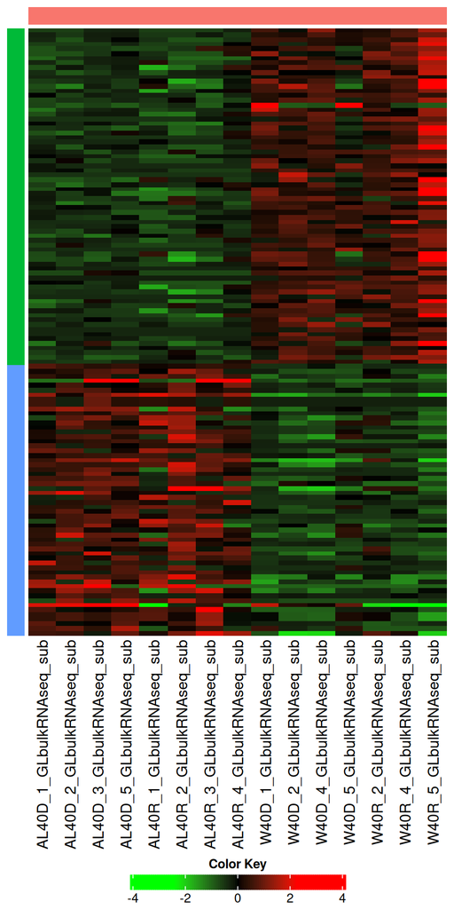

```r
if (!is.null(params$heat_data) && !is.null(params$heat_bar)) {
  heat_colors <- unlist(strsplit(params$heatmap_color_select, "-"))

  deg_heatmap(
    df = params$heat_data,
    bar = params$heat_bar,
    heatmap_color_select = heat_colors,
    cluster_rows = FALSE
  )
}
```

## Volcano Plot

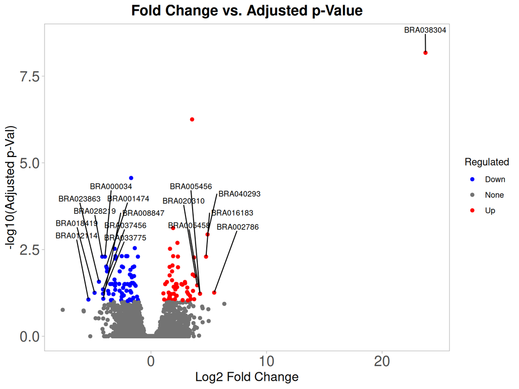

```r
if (!is.null(params$vol_data) && !is.null(params$vol_data$data)) {
  p <- plot_volcano(
    data = params$vol_data$data,
    plot_colors = params$plot_colors,
    anotate_genes = params$gene_labels_volcano
  )
  p <- refine_ggplot2(
    p = p,
    gridline = params$plot_grid_lines,
    ggplot2_theme = params$ggplot2_theme
  )
  print(p)
}
```